# Python 的 50+ 練習：資料科學學習手冊

> 探索性資料分析

[數據交點](https://www.datainpoint.com/) | 郭耀仁 yaojenkuo@datainpoint.com

## 這個章節會登場的模組

- `pandas` 模組。
- `matplotlib` 模組。

## （複習）現代資料科學：以程式設計做資料科學的應用

[figure not shown]

來源：[R for Data Science](https://r4ds.had.co.nz)

## （複習）什麼是資料科學的應用場景

- Import 資料的載入。
- Tidy 資料清理。
- **Transform 資料外型與類別的轉換**。
- **Visualise 探索性分析**。
- Model 分析與預測模型。
- Communicate 溝通分享。

## （複習）根據說明文件的範例載入

實際上主要在使用的是 `matplotlib.pyplot`

來源：https://matplotlib.org/stable/tutorials/introductory/usage.html#sphx-glr-tutorials-introductory-usage-py

```python
import matplotlib.pyplot as plt
```

## （複習）視覺化的標準五步驟

1. 建立 `ndarray`
2. 建立「畫布物件」與「軸物件」。
3. 使用「軸物件」的作圖方法建立主要圖形。
4. 使用「軸物件」的作圖方法添加圖形元素。
5. 顯示或者儲存圖形。

## 軸物件不同的方法對應不同的主要圖形

- `AxesSubplot.hist()` 觀察分配的直方圖。
- `AxesSubplot.scatter()` 觀察相關的散佈圖。
- `AxesSubplot.plot()` 觀察趨勢的線圖。
- `AxesSubplot.barh()` 觀察排序的長條圖。
- ...等。

## 不同探索目的主要圖形

## 觀察分配的直方圖

`AxesSubplot.hist()` 輸入一個數值 `ndarray`

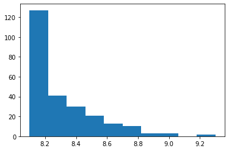

```python
import pandas as pd

movies = pd.read_csv("/home/jovyan/data/internet-movie-database/movies.csv")
ratings = movies["rating"].values
fig, ax = plt.subplots()
ax.hist(ratings)
plt.show()
```

## 觀察相關的散佈圖

`AxesSubplot.scatter()` 輸入兩個數值 `ndarray`

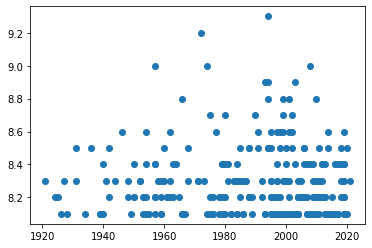

```python
release_years = movies["release_year"].values
ratings = movies["rating"].values
fig, ax = plt.subplots()
ax.scatter(release_years, ratings)
plt.show()
```

## 觀察趨勢的線圖

`AxesSubplot.plot()` 輸入一個日期時間、一個數值 `ndarray`

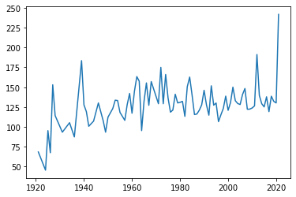

```python
runtime_by_years = movies.groupby("release_year")["runtime"].mean()
distinct_years = runtime_by_years.index
mean_runtimes = runtime_by_years.values
fig, ax = plt.subplots()
ax.plot(distinct_years, mean_runtimes)
plt.show()
```

## 觀察排序的長條圖

`AxesSubplot.barh()` 輸入一個文字序列、一個數值 `ndarray`

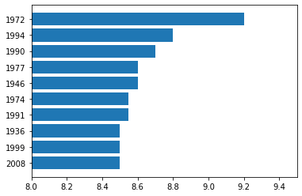

```python
rating_by_years = movies.groupby("release_year")["rating"].mean().sort_values()
top_ten_rating_by_years = rating_by_years[-10:]
distinct_years = top_ten_rating_by_years.index.astype(str)
mean_ratings = top_ten_rating_by_years.values
fig = plt.figure()
ax = plt.axes()
ax.barh(distinct_years, mean_ratings)
ax.set_xlim(8, 9.5)
plt.show()
```

## 添加圖形元素

## 常用的圖形元素

- 添加標題與軸標籤。
- 調整軸刻度。
- 調整軸刻度標籤。
- 調整軸的上下限。
- 添加文字。
- 添加圖例。

## 如何添加標題與軸標籤

- 使用 `AxesSubplot.set_title()` 添加標題。
- 使用 `AxesSubplot.set_xlabel()` 添加 x 軸標籤。
- 使用 `AxesSubplot.set_ylabel()` 添加 y 軸標籤。

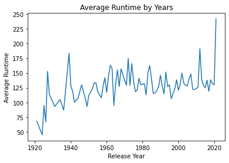

```python
runtime_by_years = movies.groupby("release_year")["runtime"].mean()
distinct_years = runtime_by_years.index
mean_runtimes = runtime_by_years.values
fig, ax = plt.subplots()
ax.plot(distinct_years, mean_runtimes)
ax.set_title("Average Runtime by Years") # title
ax.set_xlabel("Release Year")            # x-axis label
ax.set_ylabel("Average Runtime")         # y-axis label
plt.show()
```

## 如何調整軸刻度

- 使用 `AxesSubplot.set_xticks()` 調整 x 軸刻度。
- 使用 `AxesSubplot.set_yticks()` 調整 y 軸刻度。

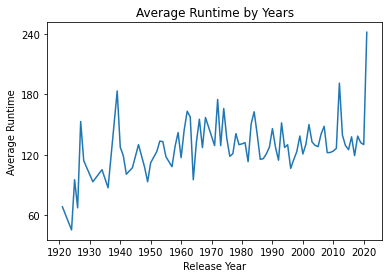

```python
fig, ax = plt.subplots()
ax.plot(distinct_years, mean_runtimes)
ax.set_title("Average Runtime by Years")
ax.set_xlabel("Release Year")
ax.set_ylabel("Average Runtime")
ax.set_xticks(range(1920, 2030, 10)) # narrow ticks
ax.set_yticks([60, 120, 180, 240])   # specify ticks
plt.show()
```

## 如何調整軸刻度標籤

- 使用 `AxesSubplot.set_xticklabels()` 調整 x 軸刻度標籤。
- 使用 `AxesSubplot.set_yticklabels()` 調整 y 軸刻度標籤。

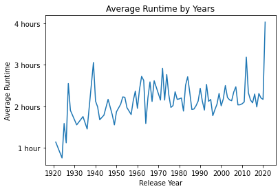

```python
fig, ax = plt.subplots()
ax.plot(distinct_years, mean_runtimes)
ax.set_title("Average Runtime by Years")
ax.set_xlabel("Release Year")
ax.set_ylabel("Average Runtime")
ax.set_xticks(range(1920, 2030, 10))
ax.set_yticks([60, 120, 180, 240])
ax.set_yticklabels(["1 hour", "2 hours", "3 hours", "4 hours"]) # specify ticklabels
plt.show()
```

## 如何調整軸的上下限

- 使用 `AxesSubplot.set_xlim()` 調整 x 軸的上下限。
- 使用 `AxesSubplot.set_ylim()` 調整 y 軸的上下限。

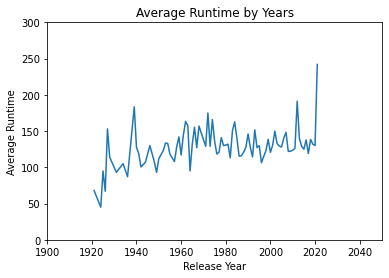

```python
fig, ax = plt.subplots()
ax.plot(distinct_years, mean_runtimes)
ax.set_title("Average Runtime by Years")
ax.set_xlabel("Release Year")
ax.set_ylabel("Average Runtime")
ax.set_xlim(1900, 2050) # set x-limits
ax.set_ylim(0, 300)     # set y-limits
plt.show()
```

## 如何添加文字

使用 `AxesSubplot.text(x, y, 'Some Strings')` 在 `(x, y)` 的位置添加 `'Some Strings'`

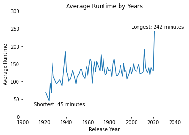

```python
fig, ax = plt.subplots()
ax.plot(distinct_years, mean_runtimes)
ax.set_title("Average Runtime by Years")
ax.set_xlabel("Release Year")
ax.set_ylabel("Average Runtime")
ax.set_xlim(1900, 2050) # set x-limits
ax.set_ylim(0, 300)     # set y-limits
ax.text(1910, 30, f"Shortest: {mean_runtimes.min():.0f} minutes") # add text at (1910, 30)
ax.text(2000, 250, f"Longest: {mean_runtimes.max():.0f} minutes") # add text at (2000, 250)
plt.show()
```

## 如何添加圖例

- 使用 `Figure.legend()` 並在主要圖形加上 `label` 參數。
- 因為 `runtime` 與 `rating` 的量尺不同，使用 `AxesSubplot.twinx()` 製作雙軸（Dual-axis）

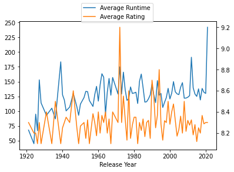

```python
runtime_by_years = movies.groupby("release_year")["runtime"].mean()
rating_by_years = movies.groupby("release_year")["rating"].mean()
distinct_years = runtime_by_years.index
mean_runtimes = runtime_by_years.values
mean_ratings = rating_by_years.values
fig, ax1 = plt.subplots()
ax1.plot(distinct_years, mean_runtimes, color="tab:blue", label="Average Runtime")
ax1.set_xlabel("Release Year")
ax2 = ax1.twinx()
ax2.plot(distinct_years, mean_ratings, color="tab:orange", label="Average Rating")
fig.legend(loc="upper center")
plt.show()
```

## 繪製子圖

## 什麼是子圖

子圖（Subplots）指的是在一個畫布物件上有多個軸物件的組成結構，多個軸物件就稱為子圖。

## 如何在一個畫布上建立子圖

使用 `plt.subplots()` 時採預設，輸出是一個 `Figure` 類別以及一個 `AxesSubplot` 類別。

```
<class 'matplotlib.figure.Figure'>
<class 'matplotlib.axes._subplots.AxesSubplot'>
```

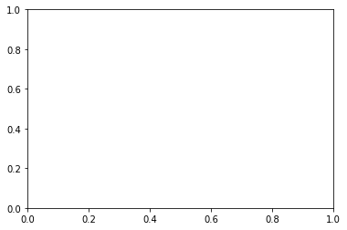

```python
fig, ax = plt.subplots() # no inputs
print(type(fig))
print(type(ax))
```

## 如何在一個畫布上建立子圖（續）

使用 `plt.subplots()` 時輸入 `m, n`，輸出變為一個 `Figure` 類別以及一個外型為 `(m, n)` 的 `ndarray` 類別。

```
<class 'matplotlib.figure.Figure'>
<class 'numpy.ndarray'>
```

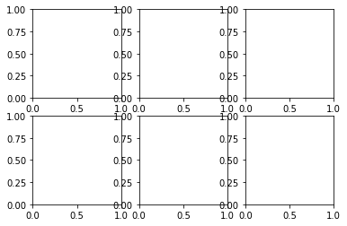

```python
fig, axes = plt.subplots(2, 3)
print(type(fig))
print(type(axes))
```

## 可以使用作圖方法、添加圖形元素的軸物件到哪了呢

- 在 `ndarray` 中有 $m \times n$ 個軸物件。
- 以 `ndarray[row, column]` 就能取得位於 `(row, column)` 的軸物件。

```
(2, 3)
<class 'matplotlib.axes._subplots.AxesSubplot'>
<class 'matplotlib.axes._subplots.AxesSubplot'>
<class 'matplotlib.axes._subplots.AxesSubplot'>
<class 'matplotlib.axes._subplots.AxesSubplot'>
<class 'matplotlib.axes._subplots.AxesSubplot'>
<class 'matplotlib.axes._subplots.AxesSubplot'>
```

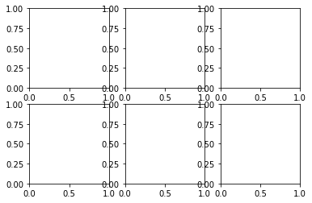

```python
m = 2
n = 3
fig, axes = plt.subplots(m, n)
print(axes.shape)
for row in range(m):
    for column in range(n):
        print(type(axes[row, column]))
```

```
(2,)
```

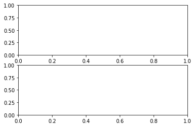

```python
fig, axes = plt.subplots(2, 1)
axes.shape
```

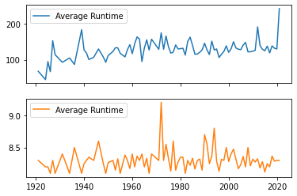

```python
fig, axes = plt.subplots(2, 1, sharex=True)
axes[0].plot(distinct_years, mean_runtimes, color="tab:blue", label="Average Runtime")
axes[0].legend(loc="upper left")
axes[1].plot(distinct_years, mean_ratings, color="tab:orange", label="Average Runtime")
axes[1].legend(loc="upper left")
plt.show()
```

## 重點統整（續）

- 常用的圖形元素
  - 添加標題與軸標籤。
  - 調整軸刻度。
  - 調整軸刻度標籤。
  - 調整軸的上下限。
  - 添加文字。
  - 添加圖例。
- 使用 `plt.subplots()` 時輸入 `m, n`，輸出變為一個 `Figure` 類別以及一個外型為 `(m, n)` 的 `ndarray` 類別，在 `ndarray` 中有 $m \times n$ 個軸物件。